# Unveiling Housing Dynamics in King County, WA

Gizem Gulsiye Guleli & Duae Marriam

2023-12-19

```r
library(ggplot2) # plots and visualizations
library(readr) #read  data
library(dplyr) #data manipulation
library(ggpubr)  # For ggarrange function
library(tidyverse) #Comprehensive package for data manipulation and visualization.
library(reshape2) # transform the data) from wide format to long format
library(plotly) # interactive visualizations
library(ggalt) #geom_encircle function
library(sf) #to read shape files -
library(sp) #convert to sf files

library(gridExtra)
library(viridis)
```

## Summary

The goal of this project is to leverage advanced visualization techniques in R to analyze house prices in King County, Washington. The dataset, obtained from Kaggle, comprises 21 variables and 21,613 observations, spanning the period from 02 May 2014 to 27 May 2015

## Objectives

Develop advanced visualizations to explore relationships between variables and understand patterns in house sales data. Try to identify and interpret factors contributing to the value of houses.

## Data

### Data Overview

```r
house_data <- read.csv("kc_house_data.csv",header = TRUE, sep = ",")
```

*Source:* Kaggle *Link:* https://www.kaggle.com/datasets/shivachandel/kc-house-data/data *Variables:* 21 (id, date, price, bedrooms, bathrooms, sqft_living, sqft_lot, floors, waterfront, view, condition, grade, sqft_above, sqft_basement, yr_built, yr_renovated, zipcode, lat, long, sqft_living15, sqft_lot15) *Observations:* 21.613 *Period:* 02 May 2014 to 27 May 2015 *Geographic coverage:* King County, including Seattle

#### Structure of Dataset

```r
str(house_data)
```

```
## 'data.frame':    21613 obs. of  21 variables:
##  $ id           : num  7.13e+09 6.41e+09 5.63e+09 2.49e+09 1.95e+09 ...
##  $ date         : chr  "20141013T000000" "20141209T000000" "20150225T000000" "20141209T000000" ...
##  $ price        : num  221900 538000 180000 604000 510000 ...
##  $ bedrooms     : int  3 3 2 4 3 4 3 3 3 3 ...
##  $ bathrooms    : num  1 2.25 1 3 2 4.5 2.25 1.5 1 2.5 ...
##  $ sqft_living  : int  1180 2570 770 1960 1680 5420 1715 1060 1780 1890 ...
##  $ sqft_lot     : int  5650 7242 10000 5000 8080 101930 6819 9711 7470 6560 ...
##  $ floors       : num  1 2 1 1 1 1 2 1 1 2 ...
##  $ waterfront   : int  0 0 0 0 0 0 0 0 0 0 ...
##  $ view         : int  0 0 0 0 0 0 0 0 0 0 ...
##  $ condition    : int  3 3 3 5 3 3 3 3 3 3 ...
##  $ grade        : int  7 7 6 7 8 11 7 7 7 7 ...
##  $ sqft_above   : int  1180 2170 770 1050 1680 3890 1715 1060 1050 1890 ...
##  $ sqft_basement: int  0 400 0 910 0 1530 0 0 730 0 ...
##  $ yr_built     : int  1955 1951 1933 1965 1987 2001 1995 1963 1960 2003 ...
##  $ yr_renovated : int  0 1991 0 0 0 0 0 0 0 0 ...
##  $ zipcode      : int  98178 98125 98028 98136 98074 98053 98003 98198 98146 98038 ...
##  $ lat          : num  47.5 47.7 47.7 47.5 47.6 ...
##  $ long         : num  -122 -122 -122 -122 -122 ...
##  $ sqft_living15: int  1340 1690 2720 1360 1800 4760 2238 1650 1780 2390 ...
##  $ sqft_lot15   : int  5650 7639 8062 5000 7503 101930 6819 9711 8113 7570 ...
```

The dataset consists of 21,613 observations (rows) and 21 variables (columns). The variables include information such as id, date, price, bedrooms, bathrooms, sqft_living, sqft_lot, floors, waterfront, view, condition, grade, sqft_above, sqft_basement, yr_built, yr_renovated, zipcode, lat, long, sqft_living15, and sqft_lot15.

The id variable appears to be a unique identifier for each observation. All variables structured as numeric/integer except the date variable which is currently stored as a character type. It might be useful to convert it to a date type for time-related analyses. So we will first convert the date variable from character to a date type.

It’s important to note that while all variables may be structured as numeric, certain variables, despite their numeric representation, hold categorical significance. These categorical variables are essentially numerically coded to represent different categories or levels within the dataset. This nuance is crucial to consider when interpreting and analyzing the data.

```r
house_data$date <- as.Date(house_data$date, format = "%Y%m%dT%H%M%S")

# Verify the changes
str(house_data$date)
```

```
##  Date[1:21613], format: "2014-10-13" "2014-12-09" "2015-02-25" "2014-12-09" "2015-02-18" ...
```

#### Summary Statistics

```r
summary(house_data)
```

```
##        id                 date                price            bedrooms
##  Min.   :1.000e+06   Min.   :2014-05-02   Min.   :  75000   Min.   : 0.000
##  1st Qu.:2.123e+09   1st Qu.:2014-07-22   1st Qu.: 321950   1st Qu.: 3.000
##  Median :3.905e+09   Median :2014-10-16   Median : 450000   Median : 3.000
##  Mean   :4.580e+09   Mean   :2014-10-29   Mean   : 540088   Mean   : 3.371
##  3rd Qu.:7.309e+09   3rd Qu.:2015-02-17   3rd Qu.: 645000   3rd Qu.: 4.000
##  Max.   :9.900e+09   Max.   :2015-05-27   Max.   :7700000   Max.   :33.000
##
##    bathrooms      sqft_living       sqft_lot           floors
##  Min.   :0.000   Min.   :  290   Min.   :    520   Min.   :1.000
##  1st Qu.:1.750   1st Qu.: 1427   1st Qu.:   5040   1st Qu.:1.000
##  Median :2.250   Median : 1910   Median :   7618   Median :1.500
##  Mean   :2.115   Mean   : 2080   Mean   :  15107   Mean   :1.494
##  3rd Qu.:2.500   3rd Qu.: 2550   3rd Qu.:  10688   3rd Qu.:2.000
##  Max.   :8.000   Max.   :13540   Max.   :1651359   Max.   :3.500
##
##    waterfront            view          condition         grade
##  Min.   :0.000000   Min.   :0.0000   Min.   :1.000   Min.   : 1.000
##  1st Qu.:0.000000   1st Qu.:0.0000   1st Qu.:3.000   1st Qu.: 7.000
##  Median :0.000000   Median :0.0000   Median :3.000   Median : 7.000
##  Mean   :0.007542   Mean   :0.2343   Mean   :3.409   Mean   : 7.657
##  3rd Qu.:0.000000   3rd Qu.:0.0000   3rd Qu.:4.000   3rd Qu.: 8.000
##  Max.   :1.000000   Max.   :4.0000   Max.   :5.000   Max.   :13.000
##
##    sqft_above   sqft_basement       yr_built     yr_renovated
##  Min.   : 290   Min.   :   0.0   Min.   :1900   Min.   :   0.0
##  1st Qu.:1190   1st Qu.:   0.0   1st Qu.:1951   1st Qu.:   0.0
##  Median :1560   Median :   0.0   Median :1975   Median :   0.0
##  Mean   :1788   Mean   : 291.5   Mean   :1971   Mean   :  84.4
##  3rd Qu.:2210   3rd Qu.: 560.0   3rd Qu.:1997   3rd Qu.:   0.0
##  Max.   :9410   Max.   :4820.0   Max.   :2015   Max.   :2015.0
##  NA's   :2
##     zipcode           lat             long        sqft_living15
##  Min.   :98001   Min.   :47.16   Min.   :-122.5   Min.   : 399
##  1st Qu.:98033   1st Qu.:47.47   1st Qu.:-122.3   1st Qu.:1490
##  Median :98065   Median :47.57   Median :-122.2   Median :1840
##  Mean   :98078   Mean   :47.56   Mean   :-122.2   Mean   :1987
##  3rd Qu.:98118   3rd Qu.:47.68   3rd Qu.:-122.1   3rd Qu.:2360
##  Max.   :98199   Max.   :47.78   Max.   :-121.3   Max.   :6210
##
##    sqft_lot15
##  Min.   :   651
##  1st Qu.:  5100
##  Median :  7620
##  Mean   : 12768
##  3rd Qu.: 10083
##  Max.   :871200
##
```

**id** - The `id` variable represents a unique identifier for each home sold.

**date** - The `date` variable, contains information about the date of the house sale and spans from May 2, 2014, to May 27, 2015.

**price:** - The `price` variable is the **dependent variable** and shows a wide range, with the minimum house price at $75,000 and the maximum at $7,700,000. - The median house price is $450,000, and the mean is $540,088.

**bedrooms and bathrooms:** - The variables related to the number of bedrooms and bathrooms (0.5 accounts for a room with a toilet but no shower) exhibit varying ranges and distributions. - The number of bedrooms ranges from 0 to 33, with a mean of approximately 3.37. - The number of bathrooms ranges from 0 to 8, with a mean of approximately 2.12.

**sqft_living and sqft_lot:** - These variables represent the size of houses. - `sqft_living` reflects the Square footage of the apartments interior living area, ranging from 290 to 13,540 square feet, with a mean of 2080. - `sqft_lot` represents the lot size, ranging from 520 to 1,651,359 square feet, with a mean of 15,107.

**floors** -The `floors` variable is represents the levels of the houses. The majority of houses have 1 or 1.5 floors. - Notably, there seems to be a common occurrence of houses with 1.5 floors, while the mean is approximately 1.494. - This suggests that many houses have a split-level design or additional space on an upper level, contributing to the fractional floor values.

**waterfront:**  
- The `waterfront` variable is a dummy variable mostly 0 , represents the property has no waterfront view and 1 for with waterfront.

**grade:** - `grade` represents the overall grade given to the housing unit and ranges from 1 to 13 where 1-3 falls short of building construction and design, 7 has an average level of construction and design, and 11-13 have a high quality level of construction and design.

**sqft_above, and sqft_basement:** - `sqft_above` and `sqft_basement` show the square footage above ground and is below ground level¶ (in the basement), respectively.

**yr_built, yr_renovated:** - Houses were built between 1900 and 2015 (`yr_built`), with the majority built in the mid to late 20th century. - `yr_renovated` indicates the last renovation year, with a mean of 84.4 and many zero values, suggesting no renovations.

**Geographical Information (lat, long, zipcode):** - `lat` and `long` provide latitude and longitude information of house locations, respectively. - `zipcode` represents the zip code of the house location.

**sqft_living15 and sqft_lot15:** - `sqft_living15` and `sqft_lot15` indicate the living room and lot size in 2015, reflecting potential renovations or changes. (? some sources mention it differently and main source couldnt find !!!)

These summary statistics provide an overview of the distribution and characteristics of each numeric variable in the dataset, with a specific focus on understanding the relationships with the **dependent variable, ‘price.’**

#### Missing Values

- Most variables in the dataset have complete data; however, it’s worth noting that `sqft_above` has two missing values (NA’s).
- Given the small number of missing values (only two observations) in relation to the overall dataset size, we have decided to remove these specific observations. This decision is based on considering the number of observations and the minimal impact on the overall analysis.
- Removing these observations ensures that the dataset remains largely complete and is a reasonable approach in this context.

```r
# Remove observations with missing values in 'sqft_above'
house_data2 <- house_data[complete.cases(house_data$sqft_above), ]
```

### Data Exploration

In organizing our variables by type, we enhance the precision of our analysis and visualization methods. This thoughtful categorization enables us to apply tailored techniques to each variable type, ensuring more insightful and nuanced exploration of the dataset.

```r
# All variables
all_vars <- house_data2[, c("price", "bedrooms", "bathrooms", "sqft_living",
                            "sqft_lot","floors", "waterfront", "view", "condition",
                            "grade", "sqft_above", "sqft_basement", "yr_built",
                            "yr_renovated", "zipcode", "lat", "long", "sqft_living15",
                            "sqft_lot15")]

# Continuous Numeric Variables
cont_vars <- c("price", "sqft_living","sqft_living15","sqft_lot",
               "sqft_lot15","sqft_above", "sqft_basement")
cont_vars2 <- c("price", "sqft_living","sqft_living15",
               "sqft_above" )

# Discrete Numeric Variables
disc_vars <- c("bedrooms", "floors", "bathrooms")

vars2 <- c("bedrooms","bathrooms", "grade")

# Categorical Variables
cat_vars <- c("waterfront", "view", "condition", "grade")

# Date Variables
date_vars <- c("date", "yr_built", "yr_renovated")

# Geographical Variables
geo_vars <- c("lat", "long", "zipcode")
```

### Exploratory Data Analysis (EDA)

Utilize various R packages (e.g., ggplot2, plotly) for data exploration. Conduct correlation analysis, distribution analysis.

```r
#  to display numeric values without scientific notation and with more digits
options(scipen = 999, digits = 9)
```

#### Distribution of Contunious Numeric Variables

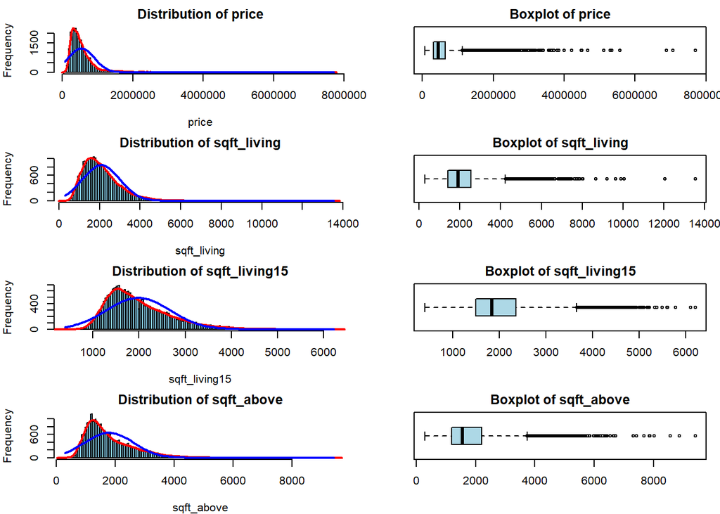

```r
# Set up a layout grid
par(mfrow = c(4, 2), mar = c(4, 4, 2, 1))  # Adjust margins for better appearance

# Create histograms for  numeric variables
for (cont in cont_vars2) {
  # Determine appropriate bin width based on the range and number of observations
  bin_width <- (max(house_data2[[cont]]) - min(house_data2[[cont]])) /
    sqrt(length(house_data2[[cont]]))

  # Create histogram with scaled x-axis
  hist(house_data2[[cont]], main = paste("Distribution of", cont), xlab = cont,
       col = "skyblue", breaks = seq(min(house_data2[[cont]]),
                                     max(house_data2[[cont]]) + bin_width, bin_width))

  # Add smoother distribution line
    density_curve <- density(house_data2[[cont]], bw = "nrd0")
    lines(density_curve$x, density_curve$y * bin_width * length(house_data2[[cont]]),
          col = "red", lwd = 2)

  # Add normal distribution line
  mu <- mean(house_data2[[cont]])
  sigma <- sd(house_data2[[cont]])
  x <- seq(min(house_data2[[cont]]), max(house_data2[[cont]]), length = 100)
  y <- dnorm(x, mean = mu, sd = sigma) * bin_width * length(house_data2[[cont]])
  lines(x, y, col = "blue", lwd = 2)

  # Identify potential outliers using a boxplot
  boxplot(house_data2[[cont]], main = paste("Boxplot of", cont), col = "lightblue",
          border = "black", horizontal = TRUE)
  }
```

```r
# Reset the plotting layout
par(mfrow = c(1, 1))
```

The visual inspection of the plots suggests that distribution of the variables are skewed right/ non-normal distributions with a considerable number of outliers. Given the context of the dataset, where very luxurious or unique properties may contribute to these extreme values, it is justifiable to observe such outliers.

Instead of removing or transforming these outliers, a more suitable strategy might involve employing robust statistical methods to handle outliers problem for further analysis. Robust methods are designed to be less sensitive to extreme values, allowing for a more reliable analysis that acknowledges the presence of these high-end properties without disproportionately impacting the results.

#### Distribution of Discrete Numeric Variables

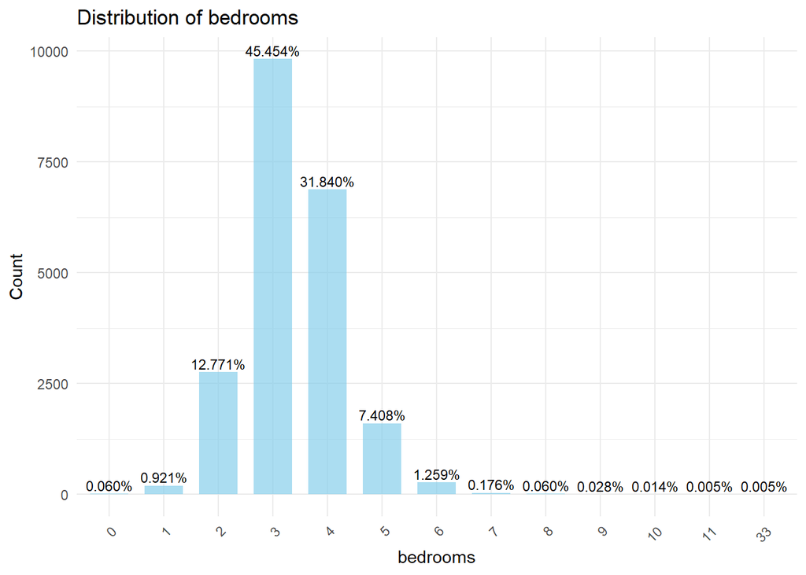

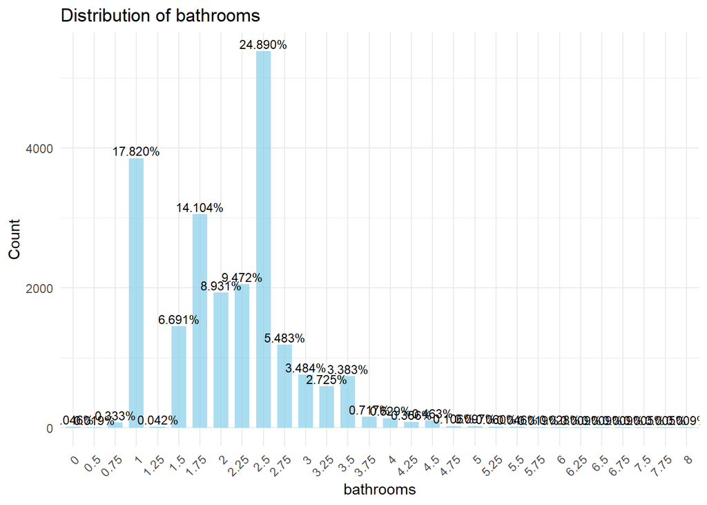

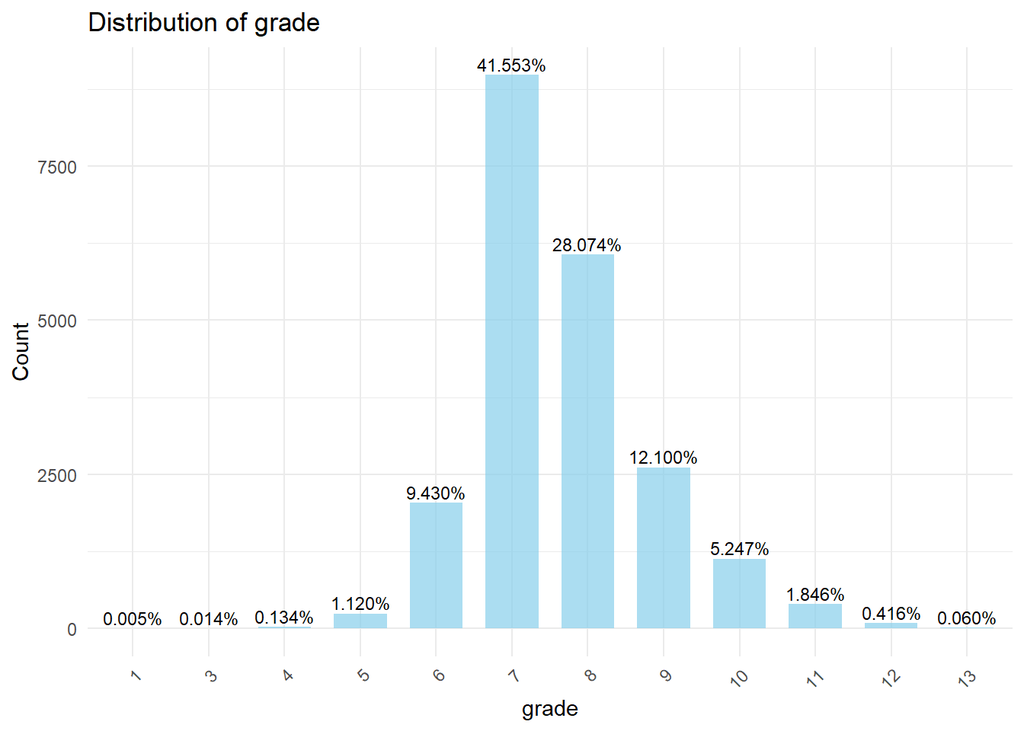

```r
# Visualize the Distribution
for (disc in vars2) {
  # Convert discrete numeric variables to factors
  house_data2[[disc]] <- as.factor(house_data2[[disc]])

  # Create bar plots for discrete numeric variables
  bar_plot <- ggplot(house_data2, aes(x = !!sym(disc), fill = !!sym(disc))) +
    geom_bar(position = "dodge", fill = "skyblue", alpha = 0.7, width = 0.7) +
    labs(title = paste("Distribution of", disc), x = disc, y = "Count") +
    theme_minimal() +
    geom_text(stat = "count",
              aes(label = scales::percent(round(after_stat(count)/sum(after_stat(count)), 5))),
              position = position_dodge(0.7), vjust = -0.3, size= 3) +  # Add percentage
    theme(axis.text.x = element_text(angle = 45, hjust = 1))  # Rotate x-axis labels

  # Display the plot
  print(bar_plot)
}
```

Bedrooms :

The distribution of bedrooms in the dataset reveals a clear preference for houses with 3 bedrooms, constituting nearly half of the entries (45.5%). 4-bedroom homes follow closely with 31.8%, and 2 and 5-bedroom configurations are also prevalent, making up 12.8% and 7.4%. However, 0-bedroom and 1-bedroom houses have notably lower percentages with approximately 0.1% and 0.9%, respectively. The distribution is positively skewed, with a peak around 3 bedrooms.

Bathrooms Configuration:

The dataset showcases a diverse distribution of bathrooms. Houses with 2.5 bathrooms are most common, representing 24.9%. Additionally, 1 bathroom and 1.75 bathrooms are prevalent at 17.8% and 14.1%, respectively. The distribution exhibits multiple peaks, suggesting a variety of bathroom count configurations in the dataset.

In the United States, bathrooms are generally categorized as master bathroom, containing a varied shower and a tub that is adjoining to a master bedroom, a “full bathroom” (or “full bath”), containing four plumbing fixtures: bathtub/shower, or (separate shower), toilet, and sink; “half (1/2) bath” (or “powder room”) containing just a toilet and sink; and “3/4 bath” containing toilet, sink, and shower, although the terms vary from market to market. In some U.S. markets, a toilet, sink, and shower are considered a “full bath”. (wikipedia)

Note on 0 Values:

In the context of houses requiring bedrooms and bathrooms, the presence of 0 values in these categories may indicate missing or incomplete data. It’s uncommon for a house to have zero bedrooms or bathrooms. Investigating and addressing the reasons behind these zero values is crucial for ensuring the quality and accuracy of the dataset, as well as the reliability of any analyses conducted.

#### Distribution of Categorical Variables

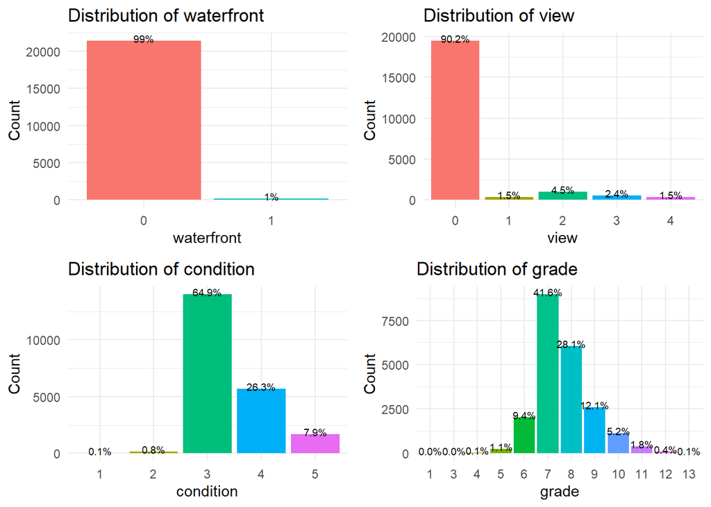

```r
# Set up a layout grid
grid_layout <- matrix(c(1, 2, 3, 4), nrow = 2, byrow = TRUE)

# Create more advanced bar plots for categorical variables
plots <- list()
for (cat in cat_vars) {
  # Convert categorical variables to factors
  house_data2[[cat]] <- as.factor(house_data2[[cat]])

  # Create bar plots for categorical variables
  bar_plot <- ggplot(house_data2, aes(x = factor(!!sym(cat)), fill =
          factor(!!sym(cat)))) + geom_bar() +geom_text(stat = "count",
    aes(label = scales::percent(round(after_stat(count)/sum(after_stat(count)), 3))),
    vjust = 0.2, size= 2.5) +  # Add percentage labels
    labs(title = paste("Distribution of", cat), x = cat, y = "Count") +
    theme_minimal() +
    theme(legend.position = "none")

  # Add the plot to the list
  plots[[cat]] <- bar_plot
}

# Arrange the plots in a 2x2 grid
grid.arrange(grobs = plots, layout_matrix = grid_layout)
```

```r
# Reset the plotting layout
par(mfrow = c(1, 1))
```

Out of all observations, only 1 percent of houses are located on the waterfront.

Additionally, the majority of houses (90.2%) have a view score of 0. Among the remaining view scores, 4.5% have a score of 2, while scores of 1 and 4 each account for 1.5%. The remaining 2.4% of houses have a view score of 3. we observed that the ‘view’ variable predominantly contained 0 values, suggesting that many houses had not been viewed. In response, we decided to engineer a new feature named ‘viewed’ to capture this information more explicitly. The ‘viewed’ variable takes on a value of 1 if the house has been viewed and 0 otherwise.

```r
# Create a new variable 'viewed' with value 1 if 'view' is not 0, and 0 otherwise
house_data2$viewed <- ifelse(house_data2$view != 0, 1, 0)

# Drop the original 'view' variable
house_data2 <- house_data2[, !names(house_data2) %in% c("view")]

# Categorical Variables
cat_vars <- c("waterfront", "viewed", "condition", "grade")
```

### Handling Zero Values in Bedroom & Bathroom

```r
# Function to impute missing values using the median based on non-zero values
impute_nonzero <- function(var) {
  non_zero_values <- as.numeric(var[var != 0])
  if (length(non_zero_values) > 0) {
    imputed_value <- median(non_zero_values)
    var[var == 0] <- imputed_value
  }
  return(var)
}

# Convert the variables to numeric again
house_data2$bedrooms <- as.numeric(as.character(house_data2$bedrooms))
house_data2$bathrooms <- as.numeric(as.character(house_data2$bathrooms))
house_data2$floors <- as.numeric(as.character(house_data2$floors))

# Apply the imputation function to bedrooms and bathrooms
house_data2$bedrooms <- impute_nonzero(house_data2$bedrooms)
house_data2$bathrooms <- impute_nonzero(house_data2$bathrooms)
```

### Correlation Analysis

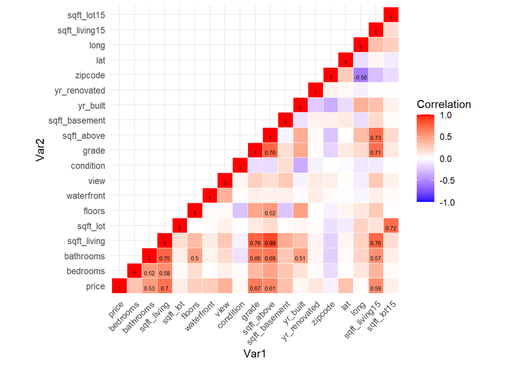

```r
# Calculate correlation for all variables
cor_matrix <- cor(all_vars)

# Set upper triangle to NA to keep only the lower triangle
cor_matrix[upper.tri(cor_matrix)] <- NA

# Create a heatmap for correlation values
melted_correlation <- melt(cor_matrix, na.rm = TRUE)

p1 <- ggplot(melted_correlation, aes(x = Var1, y = Var2, fill = value)) +
  geom_tile(color = "white") +
  scale_fill_gradient2(low = "blue", high = "red", mid = "white",
                       midpoint = 0, limit = c(-1, 1), space = "Lab",
                       name = "Correlation") +
  geom_text(aes(label = ifelse(abs(value) > 0.5, round(value, 2), "")), vjust = 1,
            size = 2) +
  theme_minimal() +
  theme(axis.text.x = element_text(angle = 45, hjust = 1)) +
  coord_fixed()

p1
```

Initially, we constructed a correlation matrix to discern relationships among variables in the dataset. To enhance interpretability, we applied a filter, selecting correlations with an absolute value greater than 0.5. This focused approach facilitates easier interpretation by highlighting strong correlated variables. The choice of the cutoff level for correlation analysis depends on the specific goals of the analysis and the nature of the data. Commonly used cutoff values for correlation coefficients between 0.5-0.7 for moderate correlation and above 0.7 for strong correlation. Eventhough we in the begging chooses 0.7 cutoff , the results showed that The price variable stands out with a strong positive correlation of 0.70 with only the square footage of living space (sqft_living). While this suggests a notable linear relationship between these two factors,we recognized it may be beneficial to also consider variables with moderate correlations to price, as they could provide additional insights into determinants of house prices beyond just living space. So we decreased the cutoff level according that.

According to final results (with 0.5 cutoff):

The Price (dependent variable): Strongly correlated with the square footage of living space (sqft_living) at 0.70, indicating that larger living spaces tend to command higher prices. And also having moderate correlation with other features such as bathrooms (0.53), sqft_above(0.61), sqft_living15(0.59) and grade(0.67)

The square footage of living space (sqft_living) demonstrates strong positive correlations with price (0.70), bathrooms (0.75), sqft_above (0.88), sqft_living15 (0.76), and grade (0.76), highlighting its multifaceted influence on house features and value. and it have moderate correlation with bedroom (0.58)

The square footage above ground (sqft_above) has the highest correlation with sqft_living (0.88) and substantial correlations with sqft_living15 (0.73) and grade (0.76), And it have moderate correlation with price (0.61), bathroom (0.69) and floors (0.52) underscoring its significance in determining overall property grades.

The overall grade (grade) exhibits a strong positive correlation with various measures of house size, including sqft_living (0.76), sqft_above (0.76), and sqft_living15 (0.71). Additionally, it shows a moderate correlation with price (0.67) and bathrooms (0.66), suggesting that houses with higher grades tend to be larger, have more bathrooms, and command higher prices.

In conclusion, the correlation analysis has uncovered intricate relationships among various features in the dataset, emphasizing the strong correlation of house prices with the square footage of living space (sqft_living). Additionally, moderate correlations with other features such as bathrooms (0.53), sqft_above (0.61), sqft_living15 (0.59), and grade (0.67) suggest the presence of diverse factors influencing property values, warranting further in-depth analysis in later stages.

Moreover, the identified potential multicollinearity issue highlights the need for careful feature selection to enhance the stability and interpretability of the regression model. Specifically, considering the strong correlations among Sqft_living, Sqft_living15, and Sqft_above, it is advisable to include only one of them in the model to avoid multicollinearity and ensure the model’s robustness.

In addition it’s crucial to remember that correlation does not imply causation. While these variables are correlated, further analysis and domain knowledge are needed to understand the causal relationships and make informed predictions.

As we move forward, advanced visualizations will serve as valuable tools to unravel these complex relationships, offering a more nuanced understanding of the dynamics shaping the real estate market in King County, Washington State, USA.

Feature Selection: Given the multicollinearity observed among sqft_living, sqft_living15, and sqft_above, we select one of these variables that best represents the living space in the model. For our case, sqft_living has a strong correlation with the target variable price and other predictors, making it a suitable choice.

## Advanced Visualization Techniques

### Scatter plots

#### Continuous variables vs. “Price”

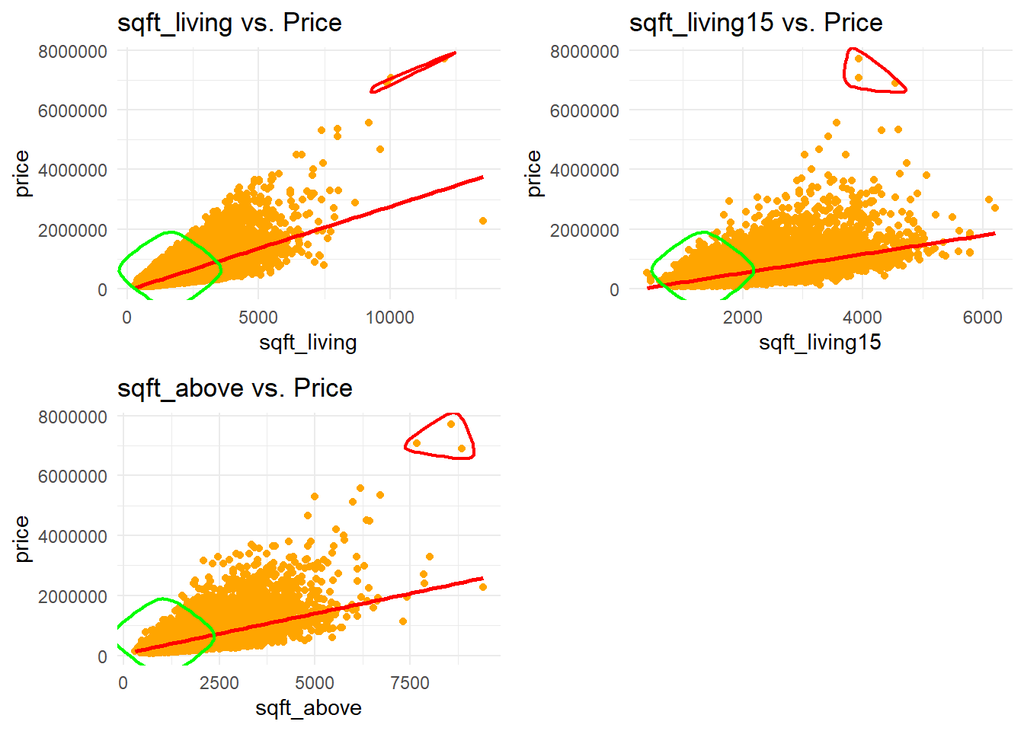

```r
attach(house_data2)

# Create an empty list to store plots
plots_list <- list()

# Iterate through variables and create scatter plots
for (variable in cont_vars2[-1]) {
  # Create scatter plot with regression line
  scatter_plot <- ggplot(house_data2, aes_string(x = variable, y = "price")) +
    geom_point(color = "orange") +
    geom_smooth(method = "lm", se = FALSE, color = "red") +
    geom_encircle(data = house_data2 %>% filter(price > 6000000),
                  color = "red", size = 2, expand = 0.05) +
     geom_encircle(data = house_data2 %>% filter(bedrooms == 33),
                  color = "green", size = 2, expand = 0.05) +
    labs(title = paste(variable, "vs. Price"), x = variable, y = "price") +
    theme_minimal()

  # Add the plot to the list
  plots_list[[variable]] <- scatter_plot
}
# Arrange the plots in a grid
advanced_plots <- ggarrange(plotlist = plots_list, ncol = 2, nrow = 2)
# Display the arranged plots
print(advanced_plots)
```

#### Discreate variables vs “Price”

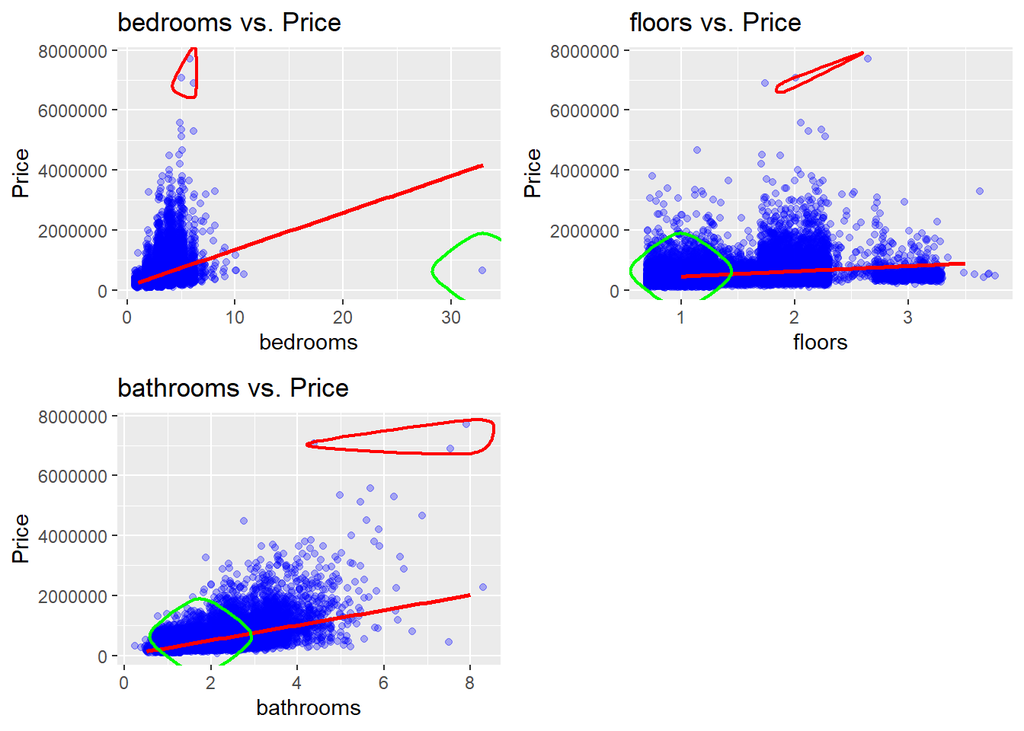

```r
# Create an empty list to store plots
plots_list <- list()

# Iterate through variables and create scatter plots
for (variable in disc_vars) {
  # Create scatter plot with regression line
  scatter_plot <- ggplot(house_data2, aes_string(x = variable, y = "price")) +
    geom_jitter(width = .3, alpha = .3, color = "blue") + # Introduce a noise
    geom_smooth(method = "lm", se = FALSE, color = "red") +
    geom_encircle(data = house_data2 %>% filter(price > 6000000),
     color = "red", size = 2, expand = 0.05) + # Add an encircling  for high prices
    geom_encircle(data = house_data2 %>% filter(bedrooms == 33),
                  color = "green", size = 2, expand = 0.05) + # Add an  encirling for
    #bedrooms == 33
    labs(title = paste(variable, "vs. Price"), x = variable, y = "Price")

  # Add the plot to the list
  plots_list[[variable]] <- scatter_plot
}

# Arrange the plots in a grid
advanced_plots <- ggarrange(plotlist = plots_list, ncol = 2, nrow = 2)
# Display the arranged plots
print(advanced_plots)
```

In this code update, we continued our exploration of the dataset by examining the relationship between housing prices and discrete variables. We introduced noise for a more nuanced view and identified high-priced outliers, visualizing them with encircling shapes.

As an additional step, we focused on the unusual case where the number of bedrooms equals 33. We specifically circled these observations using a distinctive green color. This targeted analysis aims to spotlight and investigate unique patterns and outliers within the data, enhancing our understanding of their impact on housing prices. Our approach reflects an iterative process, adapting visualizations to reveal hidden insights in the dataset.

#### Categorical variables vs. “Price”

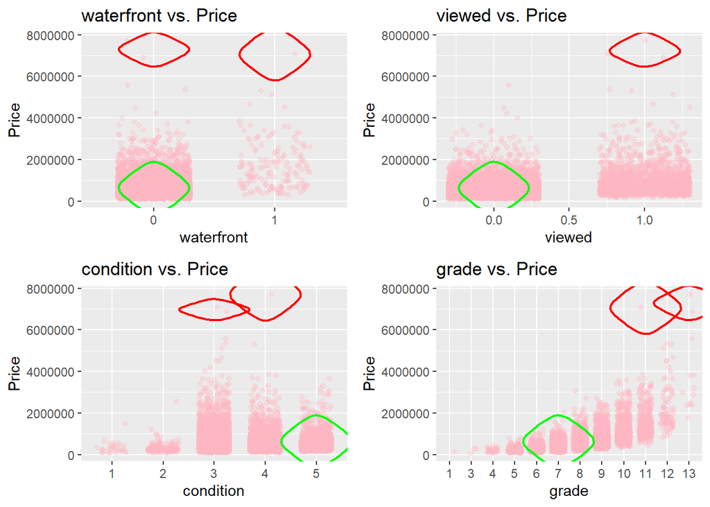

```r
# Create an empty list to store plots
plots_list <- list()

# Iterate through categorical variables and create scatter plots
for (variable in cat_vars) {
  # Create scatter plot with regression line, colored points, jitter for density, and
  ##circle for high-priced outliers
  scatter_plot <- ggplot(house_data2, aes_string(x = variable, y = "price")) +
    geom_jitter(width = .3, alpha = .3, color= "lightpink") +
    geom_encircle(data = house_data2 %>% filter(price > 6000000),
                  color = "red", size = 2, expand = 0.05) +
    geom_encircle(data = house_data2 %>% filter(bedrooms == 33),
                  color = "green", size = 2, expand = 0.05) +
    geom_encircle(data = house_data2 %>% filter(grade < 4),
                  color = "blue", size = 2, expand = 0.05) +
    labs(title = paste(variable, "vs. Price"), x = variable, y = "Price")

  # Add the plot to the list
  plots_list[[variable]] <- scatter_plot
}
# Arrange the plots in a grid
advanced_plots <- ggarrange(plotlist = plots_list, ncol = 2, nrow = 2)

# Display the arranged plots
print(advanced_plots)
```

The green-circled houses with 33 bedrooms present intriguing attributes, notably lacking waterfront features, having zero views, a condition rating of 5, and a grade higher than 5. While such characteristics are conceivable, the observed data challenges expectations, particularly in terms of the square footage of living space. The discrepancy between the expected and actual living space raises questions about potential anomalies or recording errors. To refine the accuracy and reliability of the analysis, reassessing or potentially excluding these variables is advisable. Upon detailed examination, anomalies in houses with 33 bedrooms, such as a single floor, less than 2000 sqft_living, and around 2 bathrooms, were identified as potential errors. To rectify this issue, the number of bedrooms was replaced with the median value, resulting in a more reasonable representation aligned with domain knowledge and realistic expectations.

```r
# Find indices where 'bedrooms' is 33
index_bedrooms_33 <- which(house_data2$bedrooms == 33)


# Replace the 'bedrooms' value of 33 with the median value of bedrooms
house_data2$bedrooms[index_bedrooms_33] <- median(house_data2$bedrooms, na.rm = TRUE)
```

#### Hexbin Visualization: Housing Prices and Subset Encircling

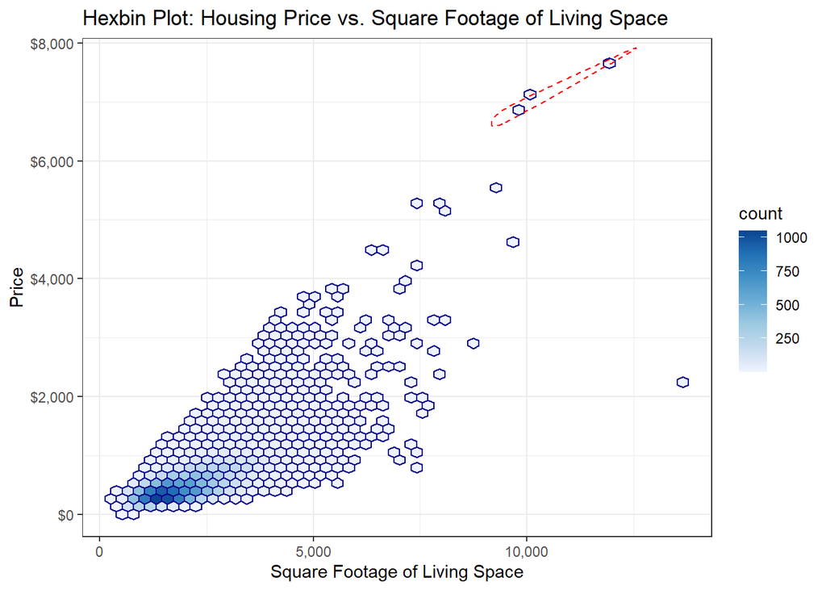

```r
# Other advanced visualizations for analysis ( hexbin)
p <- ggplot(house_data2, aes(x = sqft_living, y = price)) +
  geom_hex(bins = 50, aes(fill = ..count..), color = "darkblue") +
      geom_encircle(data = house_data2 %>% filter(bedrooms == 33),
                  color = "green", size = 2, expand = 0.05) +
    geom_encircle(data = house_data2 %>% filter(price > 6000000), color = "red", size =  1, expand = 0.05,
                linetype ="dashed") +
  labs(title = 'Hexbin Plot: Housing Price vs. Square Footage of Living Space',
       x = 'Square Footage of Living Space', y = 'Price')  +
  theme_minimal() +
  theme(axis.text.x = element_text(angle = 45, hjust = 1))

# Reverse the color scale
p +
  scale_fill_distiller(palette = "Blues", direction = 1) +
  theme_bw() +
  scale_x_continuous(labels = scales::comma) +
  scale_y_continuous(labels = scales::dollar_format(scale = 0.001))
```

#### Relationship Between Year Built, House Price, and View

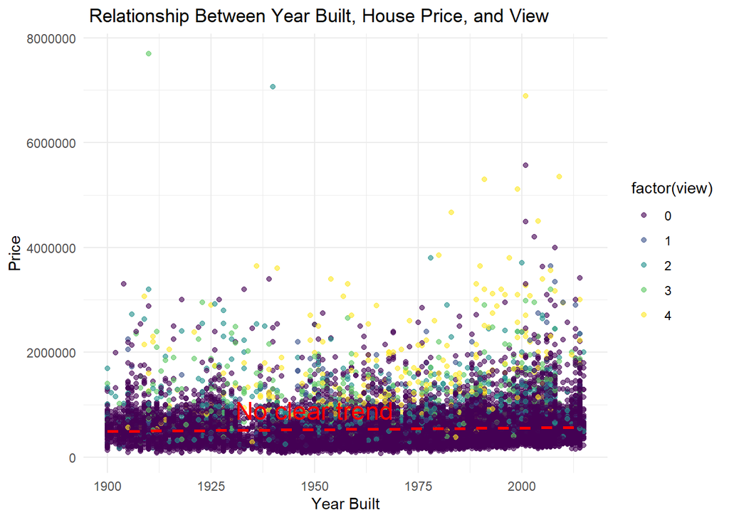

```r
options(scipen = 999, digits = 9)

# Resize the plot
options(repr.plot.width = 10, repr.plot.height = 6)

# Assuming 'house_data' is your dataframe
ggplot(house_data, aes(x = yr_built, y = price, color = factor(view))) +
  geom_point(alpha = 0.6) +
  geom_smooth(method = "lm", se = FALSE, color = "red", linetype = "dashed") +
  # Add linear regression line
  scale_color_viridis(discrete = TRUE) +
  labs(x = "Year Built", y = "Price") +
  annotate("text", x = 1950, y = 900000, label = "No clear trend", size = 6, color = "red") +  # Annotation
  theme_minimal() +
  ggtitle(" Relationship Between Year Built, House Price, and View")
```

The graph visually explores the intricate relationship among the year a house was built (‘yr_built’), its associated price, and the categorical variable ‘view.’ Each data point on the plot represents an individual house, distinguished by color based on its view category. The inclusion of a red dashed linear regression line suggests an overall trend in the data. However, in the graph we observed that, contrary to expectations, no discernible positive trend is evident within the specified range .

#### Distribution of House Prices Based on Waterfront Presence

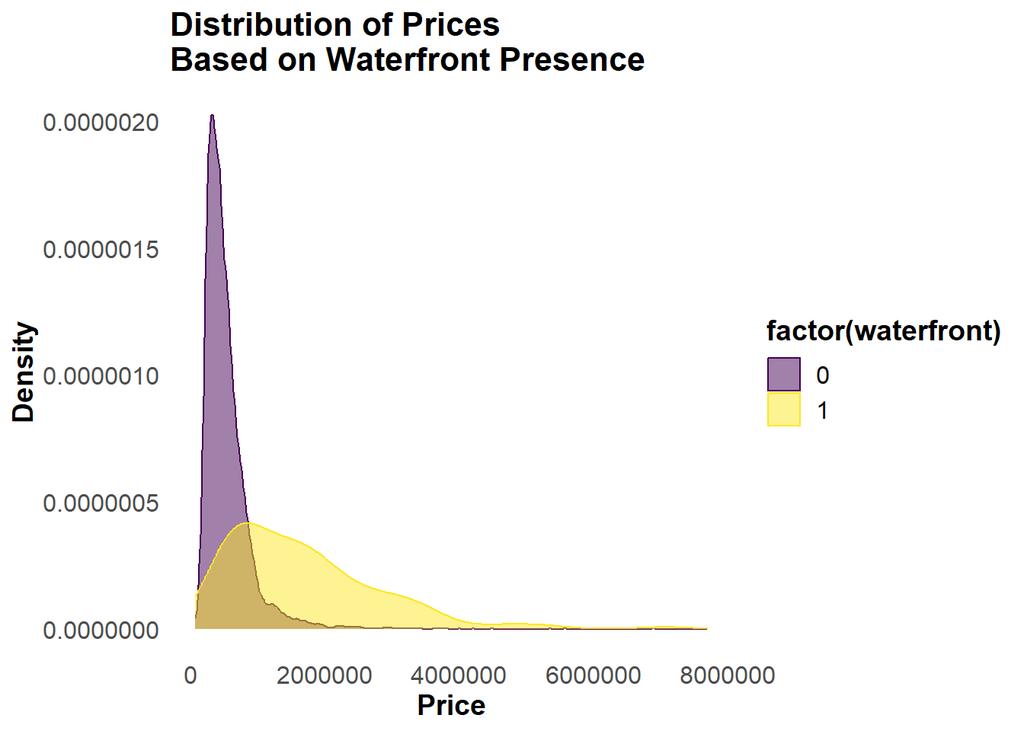

```r
# Resize the plot
options(repr.plot.width = 10, repr.plot.height = 6)

# Assuming 'house_data2' is your dataframe
ggplot(house_data2, aes(x = price, fill = factor(waterfront), color = factor(waterfront))) +
  geom_density(alpha = 0.5) +
  scale_fill_viridis(discrete = TRUE) +
  scale_color_viridis(discrete = TRUE) +
  labs(x = "Price", y = "Density") +
  theme_minimal() +
  theme(
    axis.text = element_text(size = 12),
    axis.title = element_text(size = 14, face = "bold"),
    legend.title = element_text(size = 14, face = "bold"),
    legend.text = element_text(size = 12),
    plot.title = element_text(size = 16, face = "bold"),
    panel.grid.major = element_blank(),
    panel.grid.minor = element_blank(),
    panel.background = element_blank(),
    panel.border = element_blank()
  )+
  ggtitle("Distribution of Prices\nBased on Waterfront Presence")
```

This graph visualizes the distribution of house prices categorized by the presence or absence of a waterfront. Notably, there is a substantial number of observations for non-waterfront properties, indicating a higher prevalence of such houses in the dataset. On the other hand, waterfront properties, although fewer in number, exhibit a discernible trend of higher prices. The density plot suggests that being waterfront is associated with an increase in house prices, emphasizing the potential impact of waterfront presence on the pricing structure.

#### Checking Dublicates

```r
house_data2[duplicated(house_data2), ]
```

```
##  [1] id            date          price         bedrooms      bathrooms
##  [6] sqft_living   sqft_lot      floors        waterfront    condition
## [11] grade         sqft_above    sqft_basement yr_built      yr_renovated
## [16] zipcode       lat           long          sqft_living15 sqft_lot15
## [21] viewed
## <0 rows> (or 0-length row.names)
```

```r
duplicates <- house_data2[duplicated(house_data2$id), ]
dim(duplicates)
```

```
## [1] 177  21
```

The dataset analysis provided two distinct findings regarding duplicates. First, a comprehensive scan across all columns of the dataset did not reveal any duplicate entries, suggesting the entire dataset is unique in its entirety. However, when focusing specifically on the ‘id’ column—a unique identifier for each home sold—it was discovered that 177 homes were listed with duplicate ‘id’ values. This suggests that while the dataset itself is unique, there were instances where individual homes appeared to have been sold more than once during the observed period. Such duplicates in the ‘id’ column indicate potential anomalies in the data, suggesting that certain homes may have been recorded multiple times or sold more than once, warranting a closer examination into the sales records to ensure data accuracy and integrity.

To handle it 3 approaches :

Remove Duplicates: You can choose to remove the rows with duplicate ‘id’ values. This ensures that each home is represented only once in the dataset. However, you need to carefully consider the implications of removing data, as it may result in a loss of information.

```r
# Remove rows with duplicate 'id' values
house_data2_unique <- house_data2[!duplicated(house_data2$id), ]
```

Aggregate Data: If the duplicates in the ‘id’ column represent different transactions or sales for the same home, you might want to aggregate the data. For example, you could calculate the average price, total number of bedrooms, or other relevant statistics for each unique ‘id’.

```r
# Aggregate data by 'id'
house_data2_agg<- house_data2 %>%
  group_by(id) %>%
  summarize(avg_price = mean(price),
            total_bedrooms = sum(bedrooms),
            # Add other relevant aggregations
            )
```

Feature Engineering: Instead of directly removing or aggregating duplicates, you can create new features to capture the information. For example, you might create a new binary feature indicating whether a home has been sold more than once.

```r
# Create a binary feature indicating if 'id' has duplicates
house_data2$has_duplicates <- duplicated(house_data2$id)
```

### Geospatial Visualization

We conducted a geospatial analysis to visually represent the distribution of house prices within King County and Seattle. The aim was to identify regional patterns and highlight areas with notable property values.

#### Data Acquisition and Integration

To initiate this exploration, we obtained the shapefile for King County from the website [link: https://gis-kingcounty.opendata.arcgis.com/]. Subsequently, we merged this shapefile with our existing dataset, house_data2. This integrated dataset serves as the foundation for our geospatial visualization.

```r
shape<-read_sf("zipcodeSHP/")
head(shape, 3)
```

```
## Simple feature collection with 3 features and 8 fields
## Geometry type: MULTIPOLYGON
## Dimension:     XY
## Bounding box:  xmin: 1266411.88 ymin: 97164.5685 xmax: 1303261.54 ymax: 134079.634
## Projected CRS: NAD83(HARN) / Washington North (ftUS)
## # A tibble: 3 × 9
##     ZIP ZIPCODE COUNTY ZIP_TYPE COUNTY_NAM  PREFERRED_  Shape_STAr Shape_STLe
##   <dbl> <chr>   <chr>  <chr>    <chr>       <chr>            <dbl>      <dbl>
## 1 98001 98001   033    Standard King County AUBURN      525368923.    147537.
## 2 98002 98002   033    Standard King County AUBURN      205302741     104440.
## 3 98003 98003   033    Standard King County FEDERAL WAY 316942614.    123734.
## # ℹ 1 more variable: geometry <MULTIPOLYGON [US_survey_foot]>
```

```r
merged_data <- merge(house_data2, shape, by.x = "zipcode", by.y = "ZIPCODE",
                     all.x = TRUE)
```

```r
str(merged_data)
```

```
## 'data.frame':    23307 obs. of  30 variables:
##  $ zipcode       : int  98001 98001 98001 98001 98001 98001 98001 98001 98001 98001 ...
##  $ id            : num  6699300330 3750605247 3353401710 2005950050 3522049063 ...
##  $ date          : Date, format: "2015-05-13" "2014-08-04" ...
##  $ price         : num  372000 255000 227950 260000 639900 ...
##  $ bedrooms      : num  5 3 3 3 4 3 5 3 2 3 ...
##  $ bathrooms     : num  2.5 1 1.5 2 2.5 1 2.5 1 1 1.75 ...
##  $ sqft_living   : int  2840 1710 1670 1630 3380 1370 3597 1540 1780 1840 ...
##  $ sqft_lot      : int  6010 12000 8230 8018 75794 10708 4972 37950 81021 16679 ...
##  $ floors        : num  2 1 1 1 2 1 2 1 1 1 ...
##  $ waterfront    : Factor w/ 2 levels "0","1": 1 1 1 1 1 1 1 1 1 1 ...
##  $ condition     : Factor w/ 5 levels "1","2","3","4",..: 3 4 5 3 3 3 3 4 4 3 ...
##  $ grade         : Factor w/ 12 levels "1","3","4","5",..: 7 6 6 6 9 6 6 6 8 7 ...
##  $ sqft_above    : int  2840 1710 1670 1630 3380 1370 3597 1090 1780 1840 ...
##  $ sqft_basement : int  0 0 0 0 0 0 0 450 0 0 ...
```

[output cut: 19 more lines]

```r
house_data2_avg <- house_data2 %>%
  group_by(zipcode) %>%
  summarise_all(mean, na.rm = TRUE)
# Merge the averaged datasets
merged_data_avg <- merge(house_data2_avg, shape, by.x = "zipcode",
                         by.y = "ZIPCODE", all.x = TRUE)
```

#### Comparing Geometries: King County vs. House Data

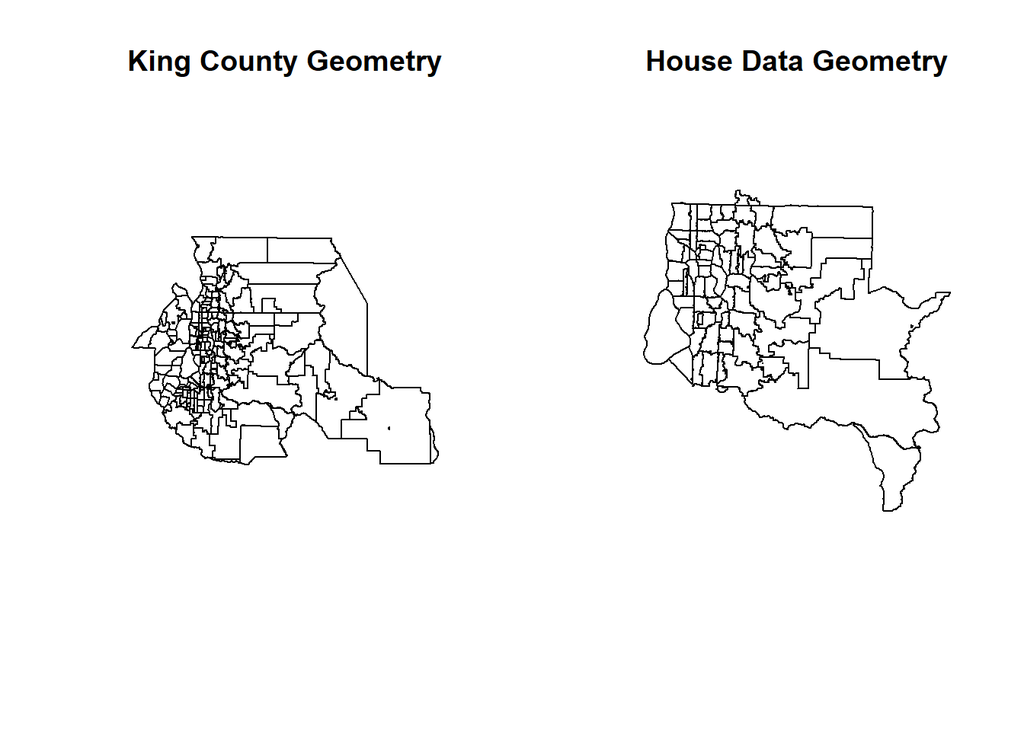

```r
# Set up a 1x2 plotting layout
par(mfrow = c(1, 2))
# Plot the geometry of the shapefile
plot(shape$geometry, main = "King County Geometry")
# Plot the geometry of the merged dataset
plot(merged_data_avg$geometry, main = "House Data Geometry")
```

The first plot displays the geometry of the King County shapefile. The second plot depicts the geometry of the merged dataset, likely representing house data.

#### Mapping House Data within King County

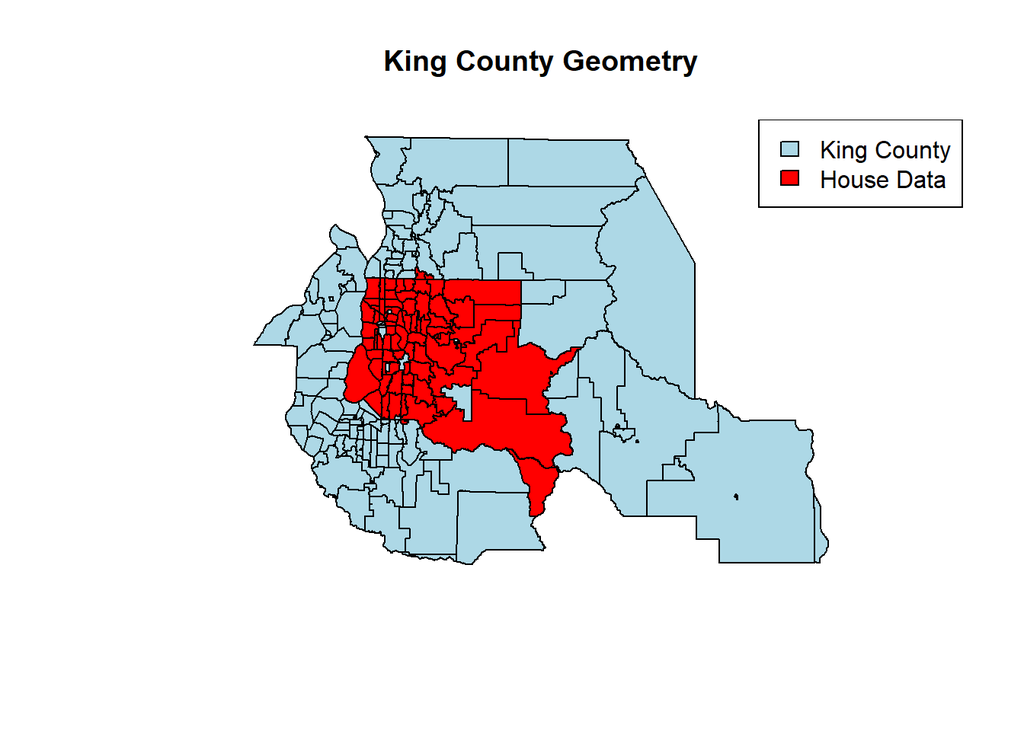

```r
# Set up a 1x2 plotting layout
par(mfrow = c(1, 1))

# Plot the geometry of the shapefile with one color (e.g., black)
plot(shape$geometry, col = "lightblue", main = "King County Geometry")

# Plot only the subset within the shapefile geometry with a different color (e.g., red)
plot(merged_data_avg$geometry, col = "red", add = TRUE)

# Add a legend
legend("topright", legend = c("King County", "House Data"),
       fill = c("lightblue", "red"))
```

The first plot shows the King County geometry in light blue. The second plot overlays the subset of the merged dataset’s geometry in red. This color differentiation and overlay help highlight the specific area covered by the house data within the broader King County context. A legend is added to clarify the color representation. The decision to use different colors for the initial mapping and overlay is to observe missing parts more clearly during the analysis process.

#### Spatial Analysis of Average House Prices: Unveiling High-Value Hotspots

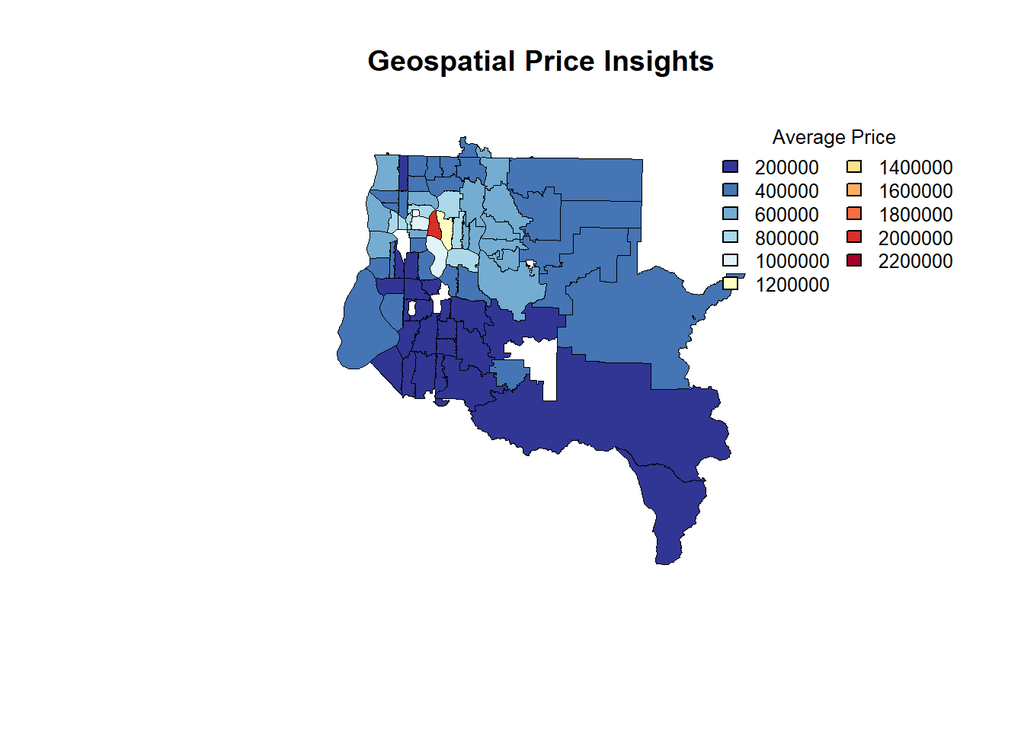

```r
# Install and load the RColorBrewer package if not already installed
if (!requireNamespace("RColorBrewer", quietly = TRUE)) {
  install.packages("RColorBrewer")
}

library(RColorBrewer)

# Generate a sequential RdYlBu color palette
custom_palette <-colorRampPalette(rev(brewer.pal(11, "RdYlBu")))

# Round the 'price' variable
merged_data_avg$rounded_price <- round(merged_data_avg$price)

# Generate a scaled sequence of rounded prices
scaled_prices <- pretty(merged_data_avg$rounded_price, 11)

# Plot the geometry with custom colors based on the rounded 'price' variable
plot(
  merged_data_avg$geometry,
  main = "Geospatial Price Insights",
  col = custom_palette(11)[cut(merged_data_avg$rounded_price, breaks = scaled_prices)],
  border = "black",  # Add black borders for better visualization
  lwd = 0.2          # Adjust the line width of borders
)

# Add legend with a scaled sequence of rounded prices
legend(
  "topright",
  legend = scaled_prices,
  fill = custom_palette(11),
  title = "Average Price",
  cex = 0.8,
  bty = "n",         # Remove box around the legend
  ncol = 2           # Set the number of columns in the legend
)
```

This mapping utilizes a sequential RdYlBu color palette to represent average house prices. The color intensity reflects the rounded prices, with a legend providing context for the color scale. Remarkably, areas with higher prices, particularly concentrated in upper central regions, are visually apparent. This spatial analysis unveils a positive spatial correlation, indicating possibility a clustering of high-value property hotspots within the mapped area.

#### Spatial Trends in Living Space: Unveiling Larger Houses

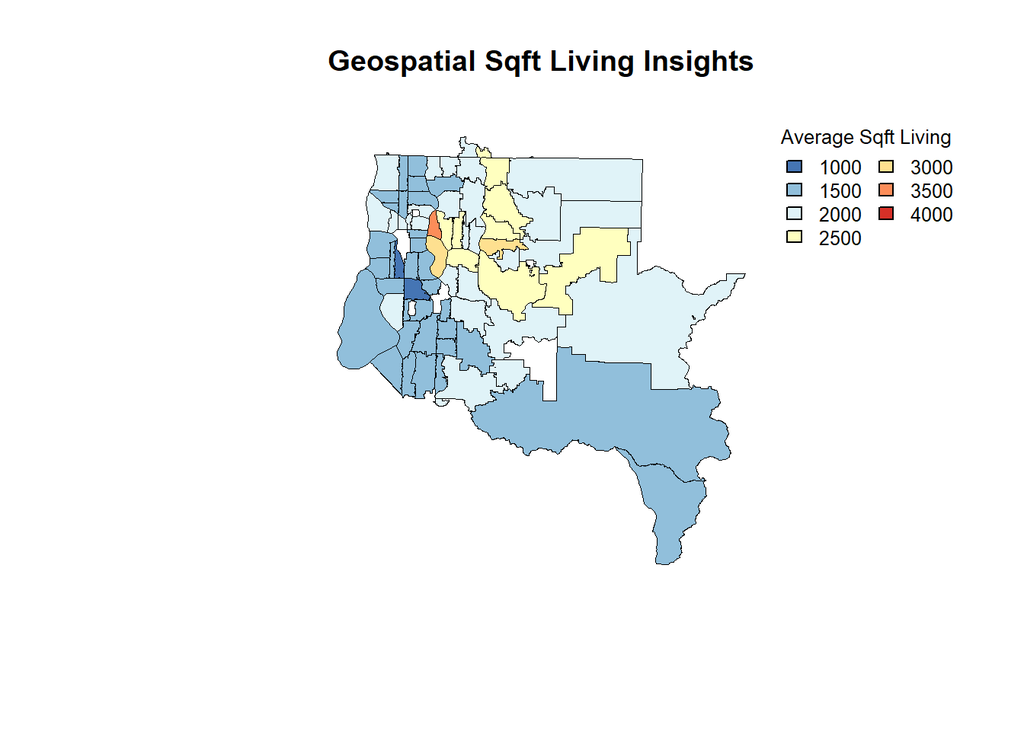

```r
# Reverse the RdYlBu color palette for sqft_living
custom_palette_sqft <- colorRampPalette(rev(brewer.pal(7, "RdYlBu")))

# Round the 'sqft_living' variable
merged_data_avg$rounded_sqft_living <- round(merged_data_avg$sqft_living)

# Generate a scaled sequence of rounded sqft_living values
scaled_sqft_living <- pretty(merged_data_avg$rounded_sqft_living, 7)

# Plot the geometry with reversed custom colors based on the rounded 'sqft_living' variable
plot(
  merged_data_avg$geometry,
  main = "Geospatial Sqft Living Insights",  # Updated title
  col = custom_palette_sqft(7)[cut(merged_data_avg$rounded_sqft_living,
                                                   breaks = scaled_sqft_living)],
  border = "black",  # Add black borders for better visualization
  lwd = 0.2          # Adjust the line width of borders
)

# Add legend with a scaled sequence of reversed rounded sqft_living values
legend(
  "topright",
  legend = scaled_sqft_living,
  fill = custom_palette_sqft(7),
  title = "Average Sqft Living",
  cex = 0.8,
  bty = "n",         # Remove box around the legend
  ncol = 2           # Set the number of columns in the legend
)
```

This code visualizes the average square footage of living space (‘sqft_living’) across the mapped area using a reversed color palette. The plot reveals that, akin to our observations with prices, larger-sized houses are concentrated in upper central regions. The color-coded spatial analysis provides insights into the distribution of living space sizes, with distinct patterns, especially in upper central areas.

#### Mapping Views: Spatial Insights into Property Perspectives

[figure not shown]

```r
# Reverse the RdYlBu color palette for view
custom_palette_view <- colorRampPalette(rev(brewer.pal(7, "RdYlBu")))


# Generate a scaled sequence of rounded view values
scaled_view <- pretty(merged_data_avg$view, 7)

# Plot the geometry with reversed custom colors based on the rounded 'view' variable
plot(
  merged_data_avg$geometry,
  main = "Geospatial View Insights",  # Updated title
  col = custom_palette_view(7)[cut(merged_data_avg$view,
                                                  breaks = scaled_view)],
  border = "black",  # Add black borders for better visualization
  lwd = 0.2          # Adjust the line width of borders
)

# Add legend with a scaled sequence of reversed rounded view values
legend(
  "topright",
  legend = scaled_view,
  fill = custom_palette_view(7),
  title = "Rounded View",
  cex = 0.8,
  bty = "n",         # Remove box around the legend
  ncol = 2           # Set the number of columns in the legend
)
```

##Resources

R Studio and associated libraries

Kaggle dataset (provided under CC0: Public Domain). https://www.kaggle.com/datasets/shivachandel/kc-house-data/data

Shapefile for mapping https://gis-kingcounty.opendata.arcgis.com/